# Linear Regression Properties and Goodness of fit

Babak Rezaee Daryakenari  
The Institute of Political Science  
Leiden University  
s.rezaeedaryakenari@fsw.leidenuniv.nl  
For more research methods handouts: https://babakrezaee.github.io

Spring 2020

# Review of the last session

The Gauss-Markov Assumptions

**1. Linearity assumption: $y=\beta_0+\beta_1 x+\epsilon$**

**2. $X$ is a full rank matrix.**

**3. $E(\epsilon|X)=0$**

**4. $E(\epsilon \epsilon'|X)=\sigma^2 I$**

**5. $X$ and $\epsilon$ are orthogonal $X \perp \epsilon$**

**6. $\epsilon | X \sim N(0,\sigma^2 I)$**

Th assumption 6 is not actually required for the Gauss-Markov Theorem. However, we often assume it to make hypothesis testing easier.

# Gauss-Markov Theorem

The **Gauss-Markov Theorem** states that, conditional on assumptions 1-5, OLS estimator is the Best Linear, Unbiased, and Efficient estimator **(BLUE)**:

1. $\hat{\beta}$ is an unbiased estimator of $\beta$.
2. $\hat{\beta}$ is a linear estimator of $\beta$.
3. $\hat{\beta}$ has minimal variance among all linear and unbiased estimators.

# Biased vs. unbiased estimation

- $E(\hat{\beta})<\beta$

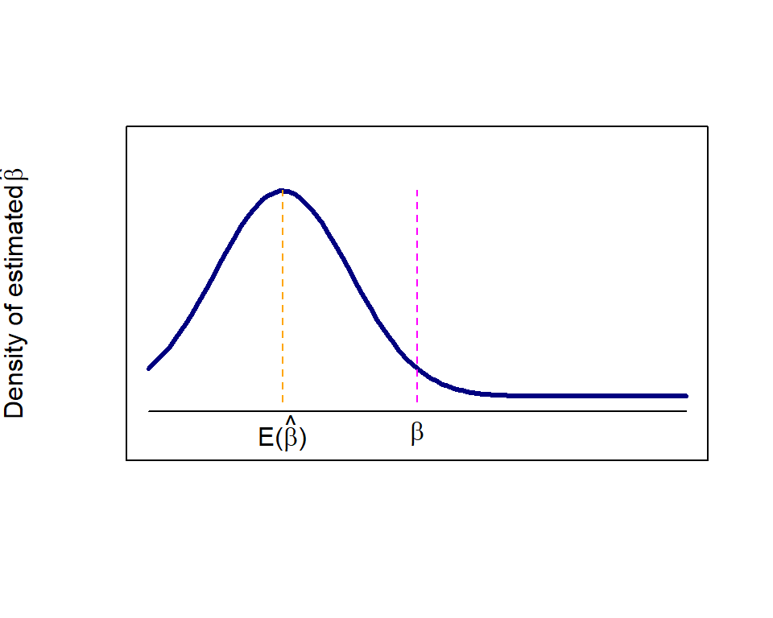

Estimations of $\beta: E(\hat{\beta})<\beta$

# Biased vs. unbiased estimation

- $E(\hat{\beta})>\beta$

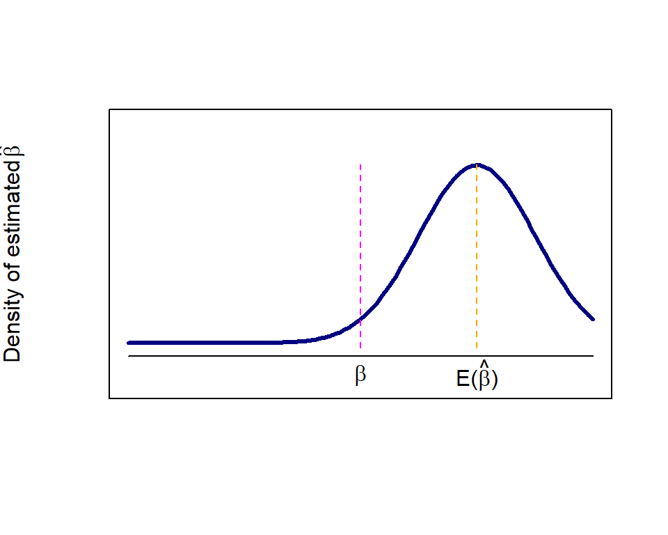

Estimations of $\beta: E(\hat{\beta})>\beta$

# Biased vs. unbiased estimation

- $E(\hat{\beta})=\beta$

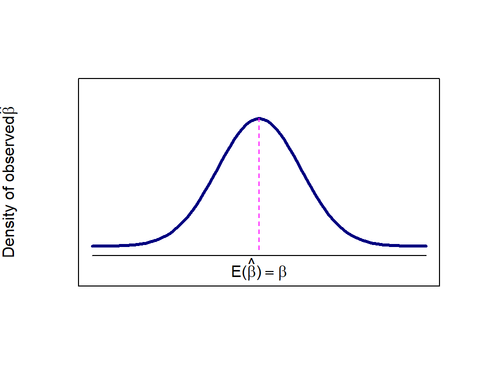

Estimations of $\beta: E(\hat{\beta})=\beta$

# Properties of OLS

# OLS regression: an example

A regression model of $y=\beta_0+\beta_1x+\epsilon$ estimated using OLS method has some properties that can help us to analyze the estimated model and whether some of the **Gauss-Markov Theorem** assumptions are satisfied.

```r
# try jtools library for cleaner regression report and of course some other interesting tools
library(jtools)
# OLS model
lin.mod <- lm(logpgp95~avexpr, data=rawData)

summ(lin.mod)
```

| Observations | 57 |
| --- | --- |
| Dependent variable | logpgp95 |
| Type | OLS linear regression |

| F(1,55) | 72.32 |
| --- | --- |
| R² | 0.57 |
| Adj. R² | 0.56 |

|  | Est. | S.E. | t val. | p |
| --- | --- | --- | --- | --- |
| (Intercept) | 4.89 | 0.38 | 12.79 | 0.00 |
| avexpr | 0.49 | 0.06 | 8.50 | 0.00 |

Standard errors: OLS

# Plotting the regression results

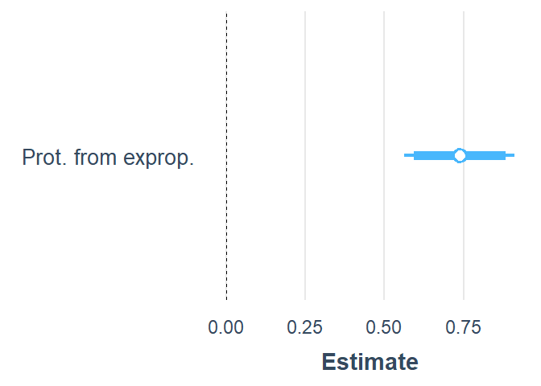

```r
## You need "ggstance" package installed for plot_summs
plot_summs(lin.mod, scale = TRUE,
           coefs = c("Prot. from exprop."="avexpr" ),
           inner_ci_level = .9)
```

# Properties of OLS: 1

The observed values of $X$ are uncorrelated with the residuals(regression errors).

```r
#Predictions
rawData$logpgp95_hat<- predict(lin.mod)
#Errors (residuals)
rawData$e_hat<- rawData$logpgp95-rawData$logpgp95_hat
```

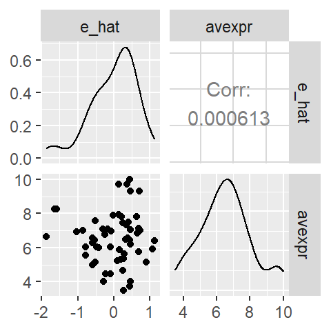

# Properties of OLS:2

The sum of the residuals is zero.

If there is a constant, then the first column in $X$ will be a column of ones. This means that for the first element in the $X'e$ vector (i.e. $X_{11}e_1+x_{21}e_2+\dots+x_{N1}e_N$) to be zero, it must be the case that $\sum_1^N e_i= 0$.

```r
sum(rawData$e_hat)
```

```
## [1] 0.00000000000001865175
```

```r
round(sum(rawData$e_hat), 3)
```

```
## [1] 0
```

# Properties of OLS: 3

The sample mean of the residuals is zero. This follows straightforwardly from the previous property, $\bar{e}=\frac{\sum_1^N e_i}{N}= 0$.

```r
mean_ehat=mean(rawData$e_hat)
round(mean_ehat,2)
```

```
## [1] 0
```

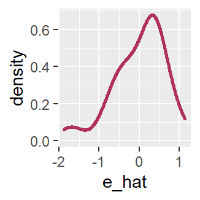

```r
library(ggplot2)

ggplot(rawData, aes(x = e_hat)) +
  geom_density(col='maroon', lwd=1)
```

# Properties of OLS: 4

The regression hyperplane, line in a bivariate model, passes through the means of the observed values ($\bar{x}$ and $\bar{y}$).

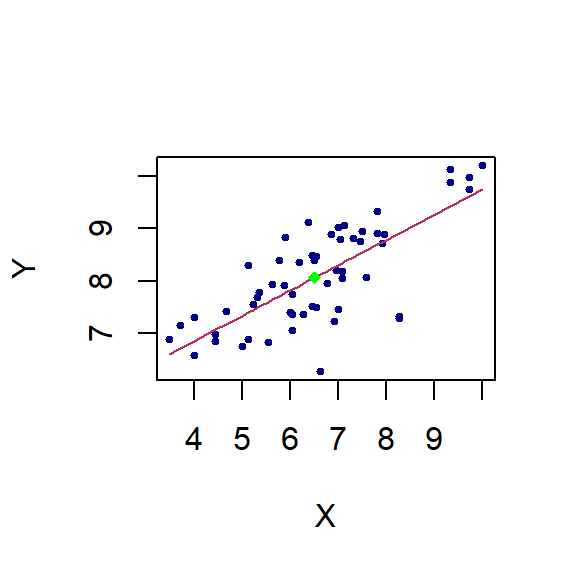

```r
plot(rawData$avexpr, rawData$logpgp95 , col="navy", pch=19, cex=.5,
     xlab="X", ylab="Y")
lines(logpgp95_hat~avexpr,data=rawData , col="maroon", lwd=1)
points(mean(rawData$avexpr), mean(rawData$logpgp95), pch = 18, col = "green", cex = .9)
```

# Properties of OLS: 5

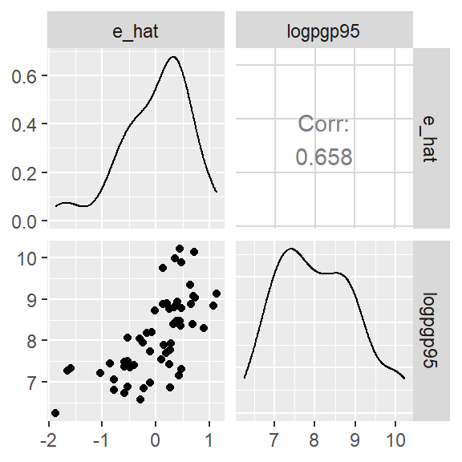

# Goodness of fit: $R^2$ and $R^2$-adjusted

# How good is an estimated regression?

- We learned about the concept of (un)biased estimation. An unbiased estimation shows that how well we quantified the association between variable $x$, or variable $x$s in multivariate regression, and variable $y$.
- Another measure of a good estimation is how much of variations in the outcome variable $y$ is explained using the independent variable(s).
- There is a subtle difference between these two measures. The first part is the focus of *causal inference* models while the second one is the focus of *prediction/forecasting* models.
- This part of the course focuses on the goodness of fit/prediction power/forecasting power/explanatory power of a regression model.

# Root of Mean Square Error

- The sum of squared errors$SSE_{OLS}$:

$$\begin{equation}
SSE_{OLS}=\sum_{i=1}^N e^2=\sum_{i=1}^N (y_1-\hat{y}_1)^2+(y_2-\hat{y}_2)^2+\dots+(y_N-\hat{y}_N)^2
\end{equation}$$

$$\begin{equation}
RMSE=\sqrt{\frac{\sum_{i=1}^N e^2}{N}}
\end{equation}$$

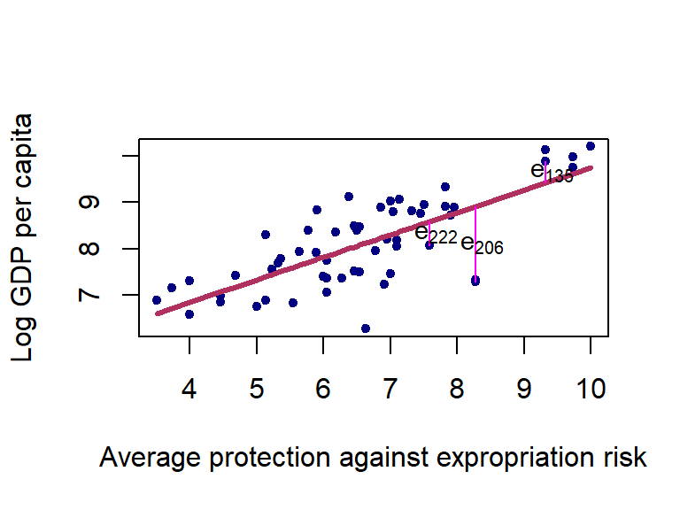

# R-squared (coefficient of determination)

- What if we want to compare RMSE with a benchmark? We can use $SSE_{\bar{y}}$:

$$\begin{equation}
SSE_{\bar{y}}=\sum_{i=1}^N(y_1-\bar{y})^2+(y_2-\bar{y})^2+\dots+(y_N-\bar{y})^2
\end{equation}$$

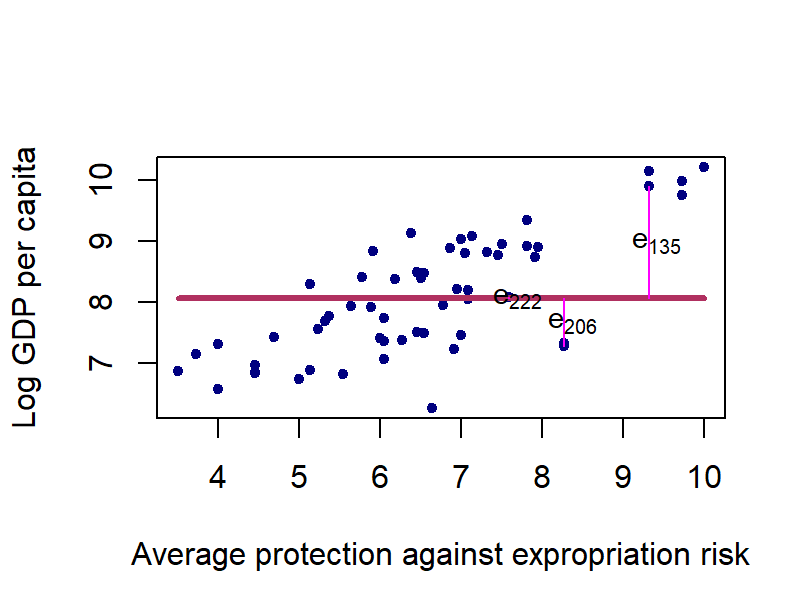

# R-squared

- How much of the variation in y, measured by $SSE_{\bar{y}}$, is not explained by the OLS model, measured $SSE_{OLS}$:

$$\begin{equation}
\frac{SSE_{OLS}}{SSE_{\bar{y}}}
\end{equation}$$

- Therefore, the amount variation in outcome $y$ that is explained by OLS is:

$$\begin{equation}
R^2=1-\frac{SSE_{OLS}}{SSE_{\bar{y}}}
\end{equation}$$

# $R^2$: An example

| Observations | 57 |
| --- | --- |
| Dependent variable | logpgp95 |
| Type | OLS linear regression |

| F(1,55) | 28.37 |
| --- | --- |
| R² | 0.34 |
| Adj. R² | 0.33 |

|  | Est. | S.E. | t val. | p |
| --- | --- | --- | --- | --- |
| (Intercept) | 7.76 | 0.12 | 64.31 | 0.00 |
| democ00a | 0.19 | 0.04 | 5.33 | 0.00 |

Standard errors: OLS

| Observations | 57 |
| --- | --- |
| Dependent variable | logpgp95 |
| Type | OLS linear regression |

| F(2,54) | 13.94 |
| --- | --- |
| R² | 0.34 |
| Adj. R² | 0.32 |

|  | Est. | S.E. | t val. | p |
| --- | --- | --- | --- | --- |
| (Intercept) | 7.74 | 0.19 | 40.15 | 0.00 |
| democ00a | 0.19 | 0.04 | 5.20 | 0.00 |
| cons1 | 0.01 | 0.05 | 0.14 | 0.89 |

Standard errors: OLS

# $R^2$-adjusted

How can we penalize unnecessary complexity of a regression model?

$$\begin{equation}
R^2_{adjusted}=1-(1-R^2)[\frac{n-1}{n-k-1}]
\end{equation}$$

where $k$ is the number of regressors.